# Rice in Colombian Sugarcane

Tim Meehan

2022-10-04

## Question

Is it possible to make Colombian sugarcane farms more bird-friendly by introducing a rice crop into the rotation?

## Set up analysis

First, load a bunch of libraries and set options.

```r
# set up
library(tibble)
library(vegan)
library(cowplot)
library(cluster)
library(NbClust)
library(glmmTMB)
library(ggplot2)
library(stringr)
library(car)
library(tidyr)
library(sf)
library(dplyr)
setwd(paste0("C:/Users/tmeehan/Box/-.Science Team shared/2_Projects/",
      "5_IAP/Valle de Cauca Colombia/Sugarcane rice surveys"))
options(scipen=99999)
options(max.print=99999)
options(stringsAsFactors=F)
```

## Get data

Next, get the data. Remove flyover birds and one species of vulture. Change the month ID so that it reflects rice stage and not actual month. Clean up column names.

```r
# get data
d1 <- read.csv("Puntos muestreo finales_v3.csv") %>%
  rename_all(tolower) %>%
  filter(!is.na(count), habitat_observed!="Flyover",
         species!="Cathartes burrovianus") %>%
  rename(rep_id=replicate, month_id=sampling_event,
         pc_station_id=point_count_id) %>%
  group_by(farm) %>%
  mutate(month_id=paste0("m", as.integer(factor(month_id)))) %>%
  ungroup() %>%
  mutate(pc_station_id=paste0("pc", str_pad(
    str_extract(pc_station_id, "[[:digit:]]+"), width=2, pad=0))) %>%
  mutate(obs_id=paste(farm, pc_station_id, month_id, rep_id, sep="_")) %>%
  select(obs_id, species, farm, pc_station_id, month_id, rep_id, count) %>%
  group_by(obs_id, species, farm, pc_station_id, month_id, rep_id) %>%
  summarise(count=max(count, na.rm=T)) %>%
  ungroup() %>%
  arrange(species, farm, pc_station_id, month_id, rep_id) %>%
  distinct()
```

## Clean data

Next, we get some data properties. We extract maximum counts per species, count site, and month. Detection probability analyses did not work out because of violated closure assumptions and very low detection probabilities. Then we zero fill the data and add US English bird names.

```r
# get some ids
spp <- sort(as.character(unique(d1$species)))
farms <- sort(as.character(unique(d1$farm)))
months <- sort(as.character(unique(d1$month_id)))
pc_stations <- sort(as.character(unique(d1$pc_station_id)))
reps <- sort(as.character(unique(d1$rep_id)))
obs_ids <- sort(as.character(unique(d1$obs_id)))

# get max counts
d2 <- d1 %>% group_by(species, farm, pc_station_id, month_id) %>%
  summarise(max_count=max(count, na.rm=T))

# all possible obs
d3 <- expand.grid(species=unique(d2$species),
                      farm=unique(d2$farm),
                      pc_station_id=unique(d2$pc_station_id),
                      month_id=unique(d2$month_id)) %>%
  left_join(d2) %>%
  mutate(max_count=ifelse(is.na(max_count), 0, max_count))

# make sure there are not all-zeros
d3 %>% group_by(farm, pc_station_id) %>%
  summarise(sum_count=sum(max_count)) %>%
  arrange(sum_count)

# join common names and habitat
d4 <- read.csv("VdC_NumberDetections_ACAD_JV.csv") %>%
  select(species=Species, eng_name=CommonName, habitat, group=Group,
         ccs_b=CCS.b) %>% right_join(d3)

# save
write.csv(d4, "zero_filled_max_count.csv", row.names=F, na="")
```

## Species traits

Next, we get species trait data so that we can make functional species groups for BFI calculation. After getting data, we reconcile species names. Then we select relevant traits. Then fill in missing body masses from Birds of the World. Then add habitat type as a species trait.

```r
# read traits table
t1 <- read.csv("EltonTraits_BirdFuncDat.csv")

# fix name mismatches
d4 %>% distinct(Scientific=species) %>%
  left_join(t1 %>% select(Scientific, English, SpecID)) %>%
  filter(is.na(English))
t1$Scientific[t1$Scientific=="Buteo magnirostris"] <- "Rupornis magnirostris"
t1$Scientific[t1$Scientific=="Casmerodius albus"] <- "Ardea alba"
t1$Scientific[t1$Scientific=="Cyanocompsa brissonii"] <- "Cyanoloxia brissonii"
t1$Scientific[t1$Scientific=="Phalacrocorax brasilianus"] <- "Nannopterum brasilianus"
t1$Scientific[t1$Scientific=="Dendroica petechia"] <- "Setophaga petechia"
t1$Scientific[t1$Scientific=="Sturnella militaris"] <- "Leistes militaris"
t1$Scientific[t1$Scientific=="Aramides cajanea"] <- "Aramides cajaneus"
t1$Scientific[t1$Scientific=="Tangara vitriolina"] <- "Stilpnia vitriolina"
t1$Scientific[t1$Scientific=="Oryzoborus crassirostris"] <- "Sporophila crassirostris"
t1$Scientific[t1$Scientific=="Gallinula chloropus"] <- "Gallinula galeata"
t1$Scientific[t1$Scientific=="Amazilia saucerrottei"] <- "Saucerottia saucerottei"
t1$Scientific[t1$Scientific=="Tryngites subruficollis"] <- "Calidris subruficollis"
t1$Scientific[t1$Scientific=="Carduelis psaltria"] <- "Spinus psaltria"
d4 %>% distinct(Scientific=species) %>%
  left_join(t1 %>% select(Scientific, English, SpecID)) %>%
  filter(is.na(English))

# filter t1 for particular species and traits
t2 <- t1 %>%
  select(Scientific,
         Diet.Inv, Diet.Vend, Diet.Vect, Diet.Vfish, Diet.Vunk, Diet.Scav,
         Diet.Fruit, Diet.Nect, Diet.Seed, Diet.PlantO,
         ForStrat.watbelowsurf, ForStrat.wataroundsurf,
         ForStrat.ground, ForStrat.understory, ForStrat.midhigh,
         ForStrat.canopy, ForStrat.aerial, BodyMass.Value) %>%
  filter(Scientific %in% unique(d4$species)) %>%
  arrange(Scientific)
summary(t2)

# fill in missing body masses from BotW
t2 %>% select(Scientific, BodyMass.Value) %>% filter(is.na(BodyMass.Value))
t2$BodyMass.Value[t2$Scientific=="Sicalis flaveola"] <- (12 + 23) / 2
t2$BodyMass.Value[t2$Scientific=="Sicalis luteola"] <- (15 + 18) / 2
t2$BodyMass.Value[t2$Scientific=="Emberizoides herbicola"] <- (21 + 37) / 2
t2$BodyMass.Value[t2$Scientific=="Volatinia jacarina"] <- (8 + 12) / 2
t2$BodyMass.Value[t2$Scientific=="Sporophila schistacea"] <- (12 + 14) / 2
t2$BodyMass.Value[t2$Scientific=="Sporophila luctuosa"] <- (12 + 13) / 2
t2$BodyMass.Value[t2$Scientific=="Sporophila nigricollis"] <- (9 + 11) / 2
t2$BodyMass.Value[t2$Scientific=="Sporophila minuta"] <- (7 + 9) / 2
t2$BodyMass.Value[t2$Scientific=="Sporophila crassirostris"] <- (20 + 22) / 2
summary(t2)

# add habitat to t2
t3 <- t2 %>%
  rename_with(~tolower(gsub(".", "_", .x, fixed=T))) %>%
  left_join(d4 %>% distinct(scientific=species, primary_habitat=habitat)) %>%
  mutate(primary_habitat=str_split(primary_habitat, ":",
                                          simplify=T)[,1],
         primary_habitat=factor(gsub(" Aerial", "", primary_habitat))) %>%
  rename(species=scientific) %>%
  bind_cols(model.matrix(~ -1 + primary_habitat, .)) %>%
  select(-primary_habitat)
```

## Make functional species

```r
# diss matirx
names(t3)
```

```
#>  [1] "species"                     "diet_inv"
#>  [3] "diet_vend"                   "diet_vect"
#>  [5] "diet_vfish"                  "diet_vunk"
#>  [7] "diet_scav"                   "diet_fruit"
#>  [9] "diet_nect"                   "diet_seed"
#> [11] "diet_planto"                 "forstrat_watbelowsurf"
#> [13] "forstrat_wataroundsurf"      "forstrat_ground"
#> [15] "forstrat_understory"         "forstrat_midhigh"
#> [17] "forstrat_canopy"             "forstrat_aerial"
#> [19] "bodymass_value"              "primary_habitatAridlands"
#> [21] "primary_habitatCoasts"       "primary_habitatForests"
#> [23] "primary_habitatGrasslands"   "primary_habitatOpen Country"
#> [25] "primary_habitatTundra"       "primary_habitatWetlands"
```

```r
d_gower <- daisy(t3[,-1], metric="gower", stand=TRUE,
                 weights=c(rep(1/2/10, 10),
                           rep(1/8/7, 7),
                           rep(1/8, 1),
                           rep(1/4/7, 7)))
# clusters
clust <- NbClust(diss=d_gower, distance=NULL, method="ward.D",
                index="silhouette")
```

```
#>
#>  Only frey, mcclain, cindex, sihouette and dunn can be computed. To compute the other indices, data matrix is needed
```

```r
# best clusters
inddf <- t3 %>% select(species) %>%
  mutate(func_spec=clust$Best.partition) %>%
  arrange(func_spec)
write.csv(inddf %>% left_join(d4 %>% distinct(species, eng_name)),
          "func_species_groupings.csv", row.names=F)
```

## Conservation scores

Then we grab conservation scores per species to produce BFI.

```r
# get conservation scores
cs1 <- read.csv("VdC_NumberDetections_ACAD_JV.csv") %>%
  select(species=Species, eng_name=CommonName, group=Group,
         ccs_b=CCS.b)
```

## Calculate BFI

Now we join the different data tables and calculate BFI components per count site and month. One component is the product of the species max count and conservation score. A second component is the Shannon diversity of functional groups. This is done twice, once for all species and once for just waterbirds. Once the components are done, all species BFI and waterbird BFI are calculated.

```r
# join functional species and conservation scores to max counts
score_wt_counts <- d4 %>% left_join(inddf) %>% left_join(cs1) %>%
  mutate(count_score=max_count*ccs_b) %>%
  select(farm, pc_station_id, month_id, count_score) %>%
  group_by(farm, pc_station_id, month_id) %>%
  summarise(tot_wt_count=sum(count_score)) %>%
  ungroup()

# join functional species and conservation scores to max counts
score_wt_counts_wb <- d4 %>% left_join(inddf) %>% left_join(cs1) %>%
  filter(group=="waterbird") %>%
  mutate(count_score=max_count*ccs_b) %>%
  select(farm, pc_station_id, month_id, count_score) %>%
  group_by(farm, pc_station_id, month_id) %>%
  summarise(tot_wt_count_wb=sum(count_score)) %>%
  ungroup()

# calc shannon
shan_div <- d4 %>% left_join(inddf) %>% left_join(cs1) %>%
  select(farm, pc_station_id, month_id, func_spec, max_count) %>%
  group_by(farm, pc_station_id, month_id, func_spec) %>%
  summarise(tot_count=sum(max_count)) %>%
  ungroup() %>%
  group_by(farm, pc_station_id, month_id) %>%
  summarise(shan=diversity(tot_count)) %>%
  ungroup() %>%
  mutate(shan=ifelse(shan==0, min(shan[shan!=0]), shan))

# calc shannon waterbirds
shan_div_wb <- d4 %>% left_join(inddf) %>% left_join(cs1) %>%
  filter(group=="waterbird") %>%
  select(farm, pc_station_id, month_id, func_spec, max_count) %>%
  group_by(farm, pc_station_id, month_id, func_spec) %>%
  summarise(tot_count=sum(max_count)) %>%
  ungroup() %>%
  group_by(farm, pc_station_id, month_id) %>%
  summarise(shan_wb=diversity(tot_count)) %>%
  ungroup() %>%
  mutate(shan_wb=ifelse(shan_wb==0, min(shan_wb[shan_wb!=0]), shan_wb))

# merge to bfi table
bfi_site <- score_wt_counts %>% left_join(shan_div) %>%
  mutate(bfi=tot_wt_count*shan) %>%
  left_join(score_wt_counts_wb) %>%
  left_join(shan_div_wb) %>%
  rename(month=month_id, station=pc_station_id) %>%
  mutate(bfi_wb=tot_wt_count_wb*shan_wb)
```

## Habitat data

Once we have BFI per count site and month, we grab the habitat data associated with each site and merge the two datasets.

```r
# get habitat data
d5 <- read.csv("Puntos muestreo finales_v3.csv") %>%
  rename_all(tolower) %>%
  filter(!is.na(count), habitat_observed!="Flyover",
         species!="Cathartes burrovianus") %>%
  rename(rep_id=replicate, month_id=sampling_event,
         pc_station_id=point_count_id) %>%
  group_by(farm) %>%
  mutate(month_id=paste0("m", as.integer(factor(month_id)))) %>%
  ungroup() %>%
  mutate(pc_station_id=paste0("pc", str_pad(
    str_extract(pc_station_id, "[[:digit:]]+"), width=2, pad=0))) %>%
  mutate(obs_id=paste(farm, pc_station_id, month_id, rep_id, sep="_")) %>%
  select(farm, station=pc_station_id, month=month_id,
         sugar=sugarcane_cover, trees=isolated_trees, bamboo=bamboo_patch,
         rice=rice_field, canal, wetland, reservoir, scrub,
         electric_pole, alley, lat=latitude, lon=longitude) %>%
  arrange(farm, station, month) %>%
  distinct()

# merge habitat and bfi
dat1 <- bfi_site %>% left_join(d5) %>% drop_na() %>%
  mutate(month_int=as.numeric(factor(month)),
         sum_rice=rice/100,
         sum_trees=(trees+bamboo+scrub)/100,
         sum_water=(canal+wetland+reservoir)/100,
         any_sugar=ifelse(sugar>0, 1, 0),
         any_rice=ifelse(rice>0, 1, 0),
         any_trees=ifelse(trees>0|bamboo>0|scrub>0, 1, 0),
         any_water=ifelse(canal>0|wetland>0|reservoir>0, 1, 0))
```

## BFI per farm

Next, we take the full data set, with site, month, BFI, and habitat, and start exploring the data with some plots. First, plot the data per farm.

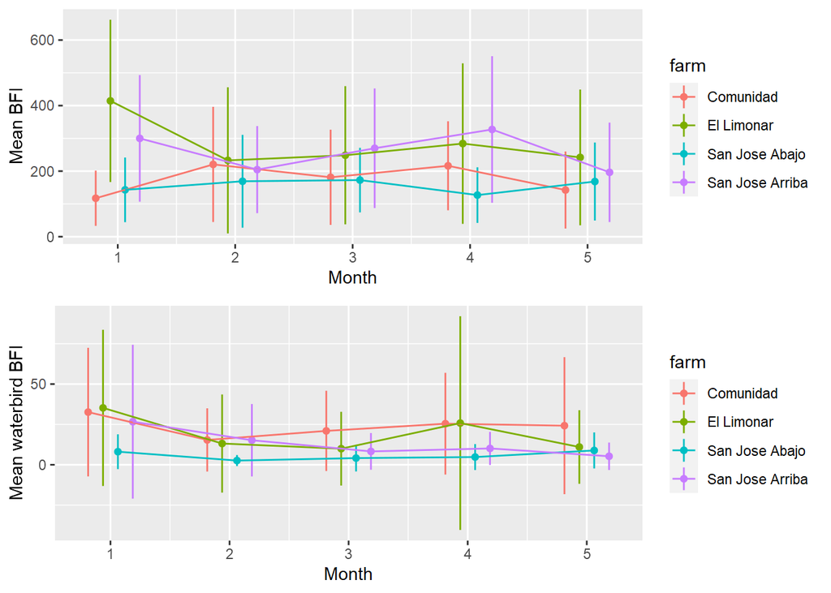

```r
# some plots
pl1 <- dat1 %>% group_by(farm, month_int) %>%
  summarise(mean_bfi=mean(bfi),
            sd_bfi=sd(bfi),
            mean_rice=mean(rice)) %>%
  ggplot(aes(x=month_int, y=mean_bfi,
             ymax=mean_bfi+sd_bfi, ymin=mean_bfi-sd_bfi,
             col=farm, group=farm)) +
  geom_point(position = position_dodge2(width = 0.5))+
  geom_linerange(position = position_dodge2(width = 0.5)) +
  geom_line(position = position_dodge2(width = 0.5)) +
  labs(x="Month", y="Mean BFI")
pl2 <- dat1 %>% group_by(farm, month_int) %>%
  summarise(mean_bfi_wb=mean(bfi_wb),
            sd_bfi_wb=sd(bfi_wb),
            mean_rice=mean(rice)) %>%
  ggplot(aes(x=month_int, y=mean_bfi_wb,
             ymax=mean_bfi_wb+sd_bfi_wb, ymin=mean_bfi_wb-sd_bfi_wb,
             col=farm, group=farm)) +
  geom_point(position = position_dodge2(width = 0.5))+
  geom_linerange(position = position_dodge2(width = 0.5)) +
  geom_line(position = position_dodge2(width = 0.5)) +
  labs(x="Month", y="Mean waterbird BFI")
plot_grid(pl1, pl2, ncol = 1)
```

## Statistical model – all species

```r
# a model
library(glmmTMB)
m1 <- glmmTMB(bfi ~ 1 + (sum_rice + sum_trees + sum_water) * month +
                (1|farm), data=dat1)
summary(m1)
```

```
#>  Family: gaussian  ( identity )
#> Formula:
#> bfi ~ 1 + (sum_rice + sum_trees + sum_water) * month + (1 | farm)
#> Data: dat1
#>
#>      AIC      BIC   logLik deviance df.resid
#>   3845.9   3927.3  -1900.9   3801.9      277
#>
#> Random effects:
#>
#> Conditional model:
#>  Groups   Name        Variance Std.Dev.
#>  farm     (Intercept)  1112     33.34
#>  Residual             19051    138.03
#> Number of obs: 299, groups:  farm, 4
#>
#> Dispersion estimate for gaussian family (sigma^2): 1.91e+04
#>
#> Conditional model:
#>                   Estimate Std. Error z value       Pr(>|z|)
#> (Intercept)         134.00      30.08   4.455 0.000008375611 ***
#> sum_rice            -60.13      55.63  -1.081         0.2797
#> sum_trees           612.46     110.45   5.545 0.000000029389 ***
#> sum_water           784.23     127.51   6.150 0.000000000773 ***
#> monthm2             -14.72      35.22  -0.418         0.6760
#> monthm3              12.95      35.22   0.368         0.7131
#> monthm4              31.94      35.51   0.899         0.3685
#> monthm5             -27.21      35.22  -0.773         0.4398
#> sum_rice:monthm2    161.97      76.52   2.117         0.0343 *
#> sum_rice:monthm3     70.59      76.52   0.923         0.3563
#> sum_rice:monthm4     28.47      76.62   0.372         0.7102
#> sum_rice:monthm5     64.79      76.52   0.847         0.3972
#> sum_trees:monthm2  -353.92     155.61  -2.274         0.0229 *
#> sum_trees:monthm3  -229.54     155.61  -1.475         0.1402
#> sum_trees:monthm4  -107.97     155.87  -0.693         0.4885
#> sum_trees:monthm5  -124.92     155.61  -0.803         0.4221
#> sum_water:monthm2  -185.73     176.26  -1.054         0.2920
#> sum_water:monthm3  -348.95     176.26  -1.980         0.0477 *
#> sum_water:monthm4  -391.44     176.57  -2.217         0.0266 *
#> sum_water:monthm5  -335.31     176.26  -1.902         0.0571 .
#> ---
#> Signif. codes:  0 '***' 0.001 '**' 0.01 '*' 0.05 '.' 0.1 ' ' 1
```

```r
Anova(m1, type=3)
```

```
#> Analysis of Deviance Table (Type III Wald chisquare tests)
#>
#> Response: bfi
#>                   Chisq Df      Pr(>Chisq)
#> (Intercept)     19.8502  1 0.0000083756112 ***
#> sum_rice         1.1683  1          0.2797
#> sum_trees       30.7474  1 0.0000000293893 ***
#> sum_water       37.8281  1 0.0000000007726 ***
#> month            3.4032  4          0.4927
#> sum_rice:month   5.1185  4          0.2754
#> sum_trees:month  5.9390  4          0.2037
#> sum_water:month  6.6655  4          0.1547
#> ---
#> Signif. codes:  0 '***' 0.001 '**' 0.01 '*' 0.05 '.' 0.1 ' ' 1
```

## Model predictions

To view the possible rice effect, we can plot a model prediction. We start with a prediction data set, then compute the model prediction, and plot it. The base case for these comparisons is 100% sugarcane, versus 50% sugarcane and 50% other.

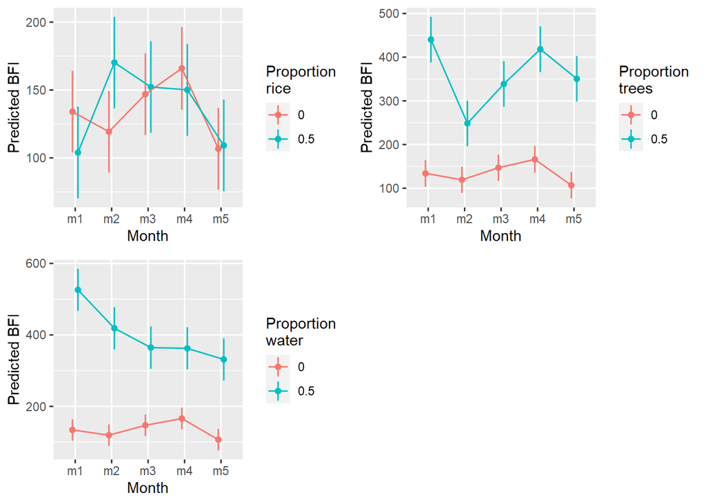

```r
# rice predictions
p1 <- dat1 %>%
  select(farm, month, sum_rice, sum_trees, sum_water) %>%
  mutate(farm=NA, sum_rice=0, sum_trees=0, sum_water=0) %>%
  distinct() %>%
  bind_rows(dat1 %>%
              select(farm, month, sum_rice, sum_trees, sum_water) %>%
              mutate(farm=NA, sum_rice=0.50, sum_trees=0, sum_water=0) %>%
              distinct())
p1$fit <- predict(m1, p1, se.fit = T)$fit
p1$se_fit <- predict(m1, p1, se.fit = T)$se.fit
pl3 <- p1 %>%
  ggplot(aes(x=month, y=fit,
             ymax=fit+se_fit, ymin=fit-se_fit,
             group=factor(sum_rice), col=factor(sum_rice))) +
  geom_point(position = position_dodge2(width = 0.3))+
  geom_linerange(position = position_dodge2(width = 0.3)) +
  geom_line(position = position_dodge2(width = 0.3)) +
  labs(x="Month", y="Predicted BFI", col="Proportion\nrice")

# trees predictions
p1 <- dat1 %>%
  select(farm, month, sum_rice, sum_trees, sum_water) %>%
  mutate(farm=NA, sum_rice=0, sum_trees=0, sum_water=0) %>%
  distinct() %>%
  bind_rows(dat1 %>%
              select(farm, month, sum_rice, sum_trees, sum_water) %>%
              mutate(farm=NA, sum_rice=0, sum_trees=0.50, sum_water=0) %>%
              distinct())
p1$fit <- predict(m1, p1, se.fit = T)$fit
p1$se_fit <- predict(m1, p1, se.fit = T)$se.fit
pl4 <- p1 %>%
  ggplot(aes(x=month, y=fit,
             ymax=fit+se_fit, ymin=fit-se_fit,
             group=factor(sum_trees), col=factor(sum_trees))) +
  geom_point(position = position_dodge2(width = 0.3))+
  geom_linerange(position = position_dodge2(width = 0.3)) +
  geom_line(position = position_dodge2(width = 0.3)) +
  labs(x="Month", y="Predicted BFI", col="Proportion\ntrees")

# water predictions
p1 <- dat1 %>%
  select(farm, month, sum_rice, sum_trees, sum_water) %>%
  mutate(farm=NA, sum_rice=0, sum_trees=0, sum_water=0) %>%
  distinct() %>%
  bind_rows(dat1 %>%
              select(farm, month, sum_rice, sum_trees, sum_water) %>%
              mutate(farm=NA, sum_rice=0, sum_trees=0, sum_water=0.50) %>%
              distinct())
p1$fit <- predict(m1, p1, se.fit = T)$fit
p1$se_fit <- predict(m1, p1, se.fit = T)$se.fit
pl5 <- p1 %>%
  ggplot(aes(x=month, y=fit,
             ymax=fit+se_fit, ymin=fit-se_fit,
             group=factor(sum_water), col=factor(sum_water))) +
  geom_point(position = position_dodge2(width = 0.3))+
  geom_linerange(position = position_dodge2(width = 0.3)) +
  geom_line(position = position_dodge2(width = 0.3)) +
  labs(x="Month", y="Predicted BFI", col="Proportion\nwater")
plot_grid(pl3, pl4, pl5)
```

## Statistical model – waterbirds

Next we create a statistical model that tests the idea that adding a rice crop to the sugarcane rotation will make the farm more bird friendly for waterbirds in particular. We find that this is indeed the case. Very clearly.

```r
# a model
m2 <- glmmTMB(bfi_wb ~ 1 + (sum_rice + sum_trees + sum_water) * month +
                (1|farm), data=dat1)
summary(m2)
```

```
#>  Family: gaussian  ( identity )
#> Formula:
#> bfi_wb ~ 1 + (sum_rice + sum_trees + sum_water) * month + (1 |      farm)
#> Data: dat1
#>
#>      AIC      BIC   logLik deviance df.resid
#>   2850.2   2931.6  -1403.1   2806.2      277
#>
#> Random effects:
#>
#> Conditional model:
#>  Groups   Name        Variance Std.Dev.
#>  farm     (Intercept)  18.59    4.311
#>  Residual             687.21   26.215
#> Number of obs: 299, groups:  farm, 4
#>
#> Dispersion estimate for gaussian family (sigma^2):  687
#>
#> Conditional model:
#>                   Estimate Std. Error z value    Pr(>|z|)
#> (Intercept)         9.9857     5.2134   1.915     0.05544 .
#> sum_rice           41.0367    10.4902   3.912 0.000091568 ***
#> sum_trees          -5.3284    20.9619  -0.254     0.79934
#> sum_water         120.3452    24.0724   4.999 0.000000575 ***
#> monthm2            -4.1567     6.6883  -0.621     0.53428
#> monthm3            -5.5813     6.6883  -0.834     0.40401
#> monthm4             0.5075     6.7449   0.075     0.94002
#> monthm5            -5.6288     6.6883  -0.842     0.40002
#> sum_rice:monthm2  -28.1185    14.5335  -1.935     0.05302 .
#> sum_rice:monthm3  -20.0666    14.5335  -1.381     0.16737
#> sum_rice:monthm4  -16.1703    14.5530  -1.111     0.26651
#> sum_rice:monthm5   -7.7562    14.5335  -0.534     0.59356
#> sum_trees:monthm2  -6.4455    29.5543  -0.218     0.82736
#> sum_trees:monthm3  -2.7965    29.5543  -0.095     0.92461
#> sum_trees:monthm4   8.8683    29.6031   0.300     0.76450
#> sum_trees:monthm5  -2.8016    29.5543  -0.095     0.92448
#> sum_water:monthm2 -62.1432    33.4765  -1.856     0.06341 .
#> sum_water:monthm3 -72.0446    33.4765  -2.152     0.03139 *
#> sum_water:monthm4 -98.2024    33.5359  -2.928     0.00341 **
#> sum_water:monthm5 -75.4141    33.4765  -2.253     0.02427 *
#> ---
#> Signif. codes:  0 '***' 0.001 '**' 0.01 '*' 0.05 '.' 0.1 ' ' 1
```

```r
Anova(m2, type=3)
```

```
#> Analysis of Deviance Table (Type III Wald chisquare tests)
#>
#> Response: bfi_wb
#>                   Chisq Df   Pr(>Chisq)
#> (Intercept)      3.6687  1      0.05544 .
#> sum_rice        15.3031  1 0.0000915679 ***
#> sum_trees        0.0646  1      0.79934
#> sum_water       24.9930  1 0.0000005754 ***
#> month            1.6010  4      0.80860
#> sum_rice:month   4.4969  4      0.34292
#> sum_trees:month  0.3051  4      0.98948
#> sum_water:month  9.6817  4      0.04614 *
#> ---
#> Signif. codes:  0 '***' 0.001 '**' 0.01 '*' 0.05 '.' 0.1 ' ' 1
```

## Model predictions

Here are prediction plots that show the magnitude of the effects.

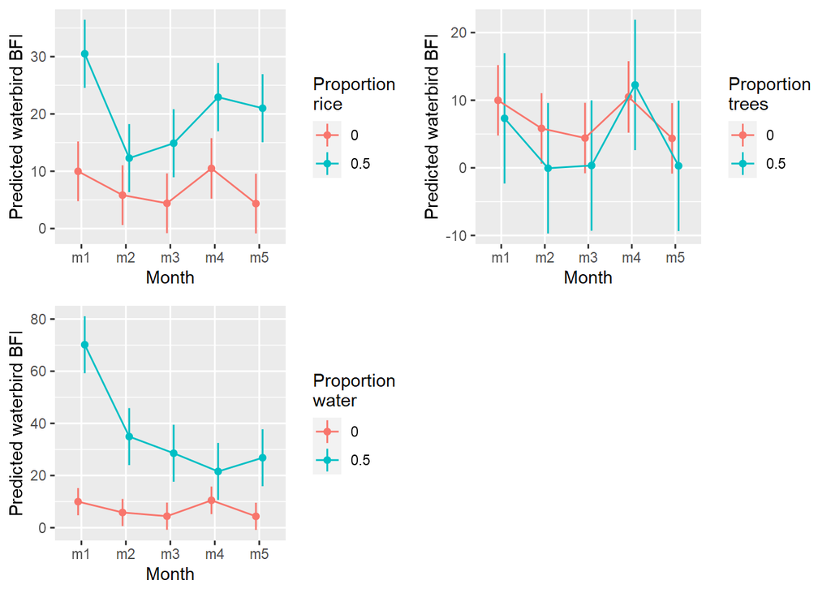

```r
# rice predictions
p1 <- dat1 %>%
  select(farm, month, sum_rice, sum_trees, sum_water) %>%
  mutate(farm=NA, sum_rice=0, sum_trees=0, sum_water=0) %>%
  distinct() %>%
  bind_rows(dat1 %>%
              select(farm, month, sum_rice, sum_trees, sum_water) %>%
              mutate(farm=NA, sum_rice=0.50, sum_trees=0, sum_water=0) %>%
              distinct())
p1$fit <- predict(m2, p1, se.fit = T)$fit
p1$se_fit <- predict(m2, p1, se.fit = T)$se.fit
pl6 <- p1 %>%
  ggplot(aes(x=month, y=fit,
             ymax=fit+se_fit, ymin=fit-se_fit,
             group=factor(sum_rice), col=factor(sum_rice))) +
  geom_point(position = position_dodge2(width = 0.3))+
  geom_linerange(position = position_dodge2(width = 0.3)) +
  geom_line(position = position_dodge2(width = 0.3)) +
  labs(x="Month", y="Predicted waterbird BFI", col="Proportion\nrice")

# trees predictions
p1 <- dat1 %>%
  select(farm, month, sum_rice, sum_trees, sum_water) %>%
  mutate(farm=NA, sum_rice=0, sum_trees=0, sum_water=0) %>%
  distinct() %>%
  bind_rows(dat1 %>%
              select(farm, month, sum_rice, sum_trees, sum_water) %>%
              mutate(farm=NA, sum_rice=0, sum_trees=0.50, sum_water=0) %>%
              distinct())
p1$fit <- predict(m2, p1, se.fit = T)$fit
p1$se_fit <- predict(m2, p1, se.fit = T)$se.fit
pl7 <- p1 %>%
  ggplot(aes(x=month, y=fit,
             ymax=fit+se_fit, ymin=fit-se_fit,
             group=factor(sum_trees), col=factor(sum_trees))) +
  geom_point(position = position_dodge2(width = 0.3))+
  geom_linerange(position = position_dodge2(width = 0.3)) +
  geom_line(position = position_dodge2(width = 0.3)) +
  labs(x="Month", y="Predicted waterbird BFI", col="Proportion\ntrees")

# water predictions
p1 <- dat1 %>%
  select(farm, month, sum_rice, sum_trees, sum_water) %>%
  mutate(farm=NA, sum_rice=0, sum_trees=0, sum_water=0) %>%
  distinct() %>%
  bind_rows(dat1 %>%
              select(farm, month, sum_rice, sum_trees, sum_water) %>%
              mutate(farm=NA, sum_rice=0, sum_trees=0, sum_water=0.50) %>%
              distinct())
p1$fit <- predict(m2, p1, se.fit = T)$fit
p1$se_fit <- predict(m2, p1, se.fit = T)$se.fit
pl8 <- p1 %>%
  ggplot(aes(x=month, y=fit,
             ymax=fit+se_fit, ymin=fit-se_fit,
             group=factor(sum_water), col=factor(sum_water))) +
  geom_point(position = position_dodge2(width = 0.3))+
  geom_linerange(position = position_dodge2(width = 0.3)) +
  geom_line(position = position_dodge2(width = 0.3)) +
  labs(x="Month", y="Predicted waterbird BFI", col="Proportion\nwater")
plot_grid(pl6, pl7, pl8)
```

## Summary

So it looks like having rice on the farm does not have a huge effect on BFI when BFI includes all species. That seems to be because, in this system, BFI is most heavily driven by woodland birds, and it makes sense that woodland birds are not highly influenced by adding rice. When looking at just waterbird BFI, having rice on the farm makes a big positive impact, which makes sense since rice is often flooded during cultivation.

## Full range of predictions

Here are model predictions for BFI under a range of proportions for trees (0 - 0.1, x), open water (0 - 0.1, y), and rice (0 - 1, panels).

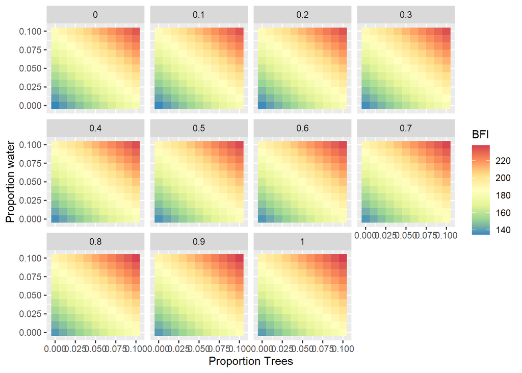

```r
# make prediction grid
m_in <- unique(dat1$month)
r_in <- seq(0, 1, length.out=11)
t_in <- seq(0, .1, length.out=11)
w_in <- seq(0, .1, length.out=11)
pred_grid <- expand.grid(farm=NA,
                         month=m_in,
                         sum_rice=r_in,
                         sum_trees=t_in,
                         sum_water=w_in)

# predict from bfi model
pred_grid$predicted <- predict(m1, newdata = pred_grid)
pred_grid_sum <- pred_grid %>%
  group_by(Rice=factor(sum_rice), Trees=factor(sum_trees), Water=factor(sum_water)) %>%
  summarise(mean_pred=mean(predicted)) %>%
  ungroup() %>%
  mutate(scale_mean_pred=plogis(as.numeric(scale(mean_pred)))) %>%
  mutate(Rice=as.numeric(as.character(Rice)),
         Trees=as.numeric(as.character(Trees)),
         Water=as.numeric(as.character(Water)))

# plot bfi
pl9 <- pred_grid_sum %>%
  ggplot(aes(x=Trees, y=Water, fill=mean_pred)) +
  geom_tile() +
  facet_wrap(~Rice) +
  labs(x="Proportion Trees", y="Proportion water", fill="BFI") +
  scale_fill_distiller(palette="Spectral")
pl9
```

Here are model predictions for waterbird BFI under a range of proportions for trees (0 - 0.1, x), open water (0 - 0.1, y), and rice (0 - 1, panels).

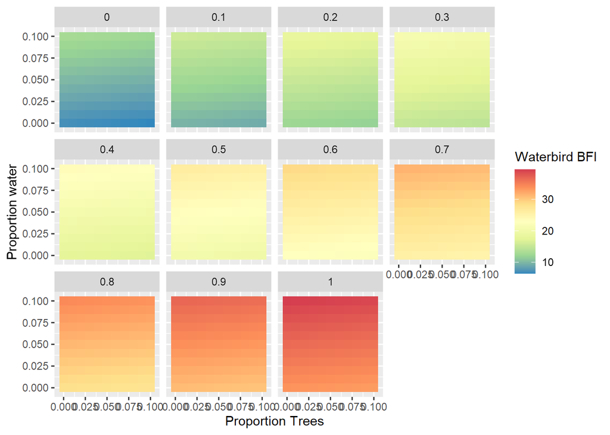

```r
#predict from waterbird bfi model
pred_grid$predicted <- predict(m2, newdata = pred_grid)
pred_grid_sum <- pred_grid %>%
  group_by(Rice=factor(sum_rice), Trees=factor(sum_trees), Water=factor(sum_water)) %>%
  summarise(mean_pred=mean(predicted)) %>%
  ungroup() %>%
  mutate(scale_mean_pred=plogis(as.numeric(scale(mean_pred)))) %>%
  mutate(Rice=as.numeric(as.character(Rice)),
         Trees=as.numeric(as.character(Trees)),
         Water=as.numeric(as.character(Water)))
pl10 <- pred_grid_sum %>%
  ggplot(aes(x=Trees, y=Water, fill=mean_pred)) +
  geom_tile() +
  facet_wrap(~Rice) +
  labs(x="Proportion Trees", y="Proportion water", fill="Waterbird BFI") +
  scale_fill_distiller(palette="Spectral")
pl10
```